# Q1

[**BankNote**](https://archive.ics.uci.edu/ml/datasets/banknote+authentication)

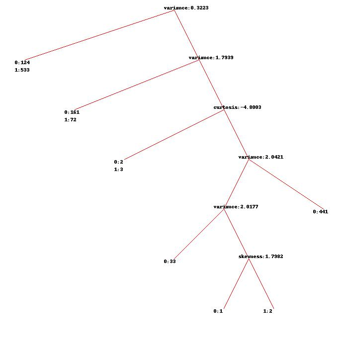

Please observe this model is very different from pessimistic error and minimum description approach.It’s accuracy came out be only ~60%.This approach is good enough only if there are lot of classes.

**(c)** **Use the minimum description length principle, as explained in Question #8, page 201 of your Textbook**  
**(soln)**  
Module:prune.py  
MDL is defined as follows:  
cost(tree,data)= cost(tree)+cost(data|tree)  
**overall cost(MDL) = (no of nodes)log2(m)+ (no of leaves)log2(k)+ (no of errors)log2(n)**

Here M=no. of attributes & K= no. of classes

I have encoded this formula and did post pruning whenever MDL increases on splitting a node in to branches.  
i,e MDL of a node(if not splitted)=(n)log2(m)+ (l)log2(k)+ e1*log2(n)  
MDL of a node (if splitted)= (n+1)log2(m) + (l+2)log2(k) + e2log2(n)

so $\delta$ = **log2(m)+ 2(log2(k)) + (e2-e1)log2(n)**  
Thus whenever delta is increasing i am pruning that node.

Here are results when i applied this sort of pruning on iris,wine,& bank dataset  
(Left side tree without pruning,Right side is tree after pruning using mdl error)

[**Iris**](https://archive.ics.uci.edu/ml/datasets/Iris)

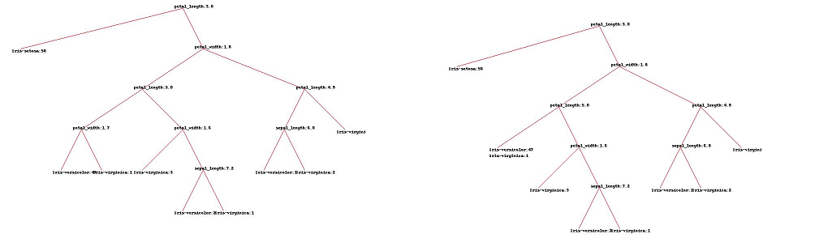

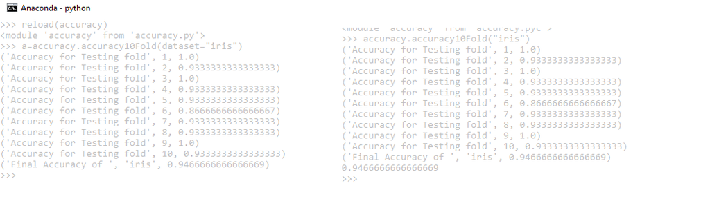

[**Wine**](https://archive.ics.uci.edu/ml/datasets/Wine)

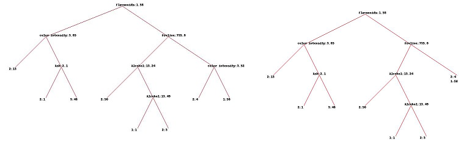

[figure not shown]

[**BankNote**](https://archive.ics.uci.edu/ml/datasets/banknote+authentication)

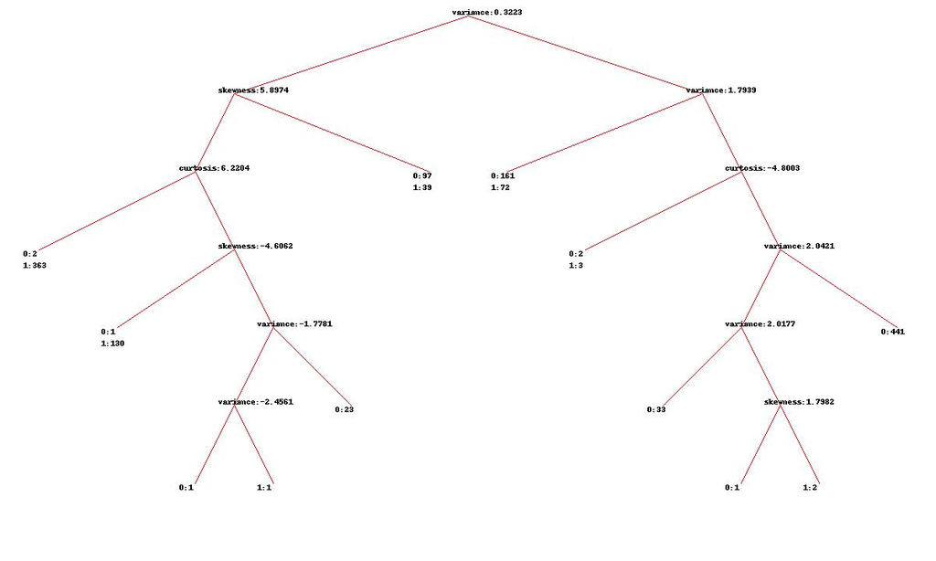

[figure not shown]

[**Iris**](https://archive.ics.uci.edu/ml/datasets/Iris)

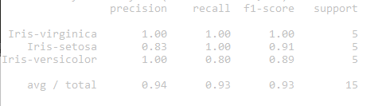

[**Wine**](https://archive.ics.uci.edu/ml/datasets/Wine)

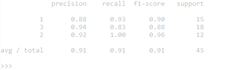

[**BankNote**](https://archive.ics.uci.edu/ml/datasets/banknote+authentication)

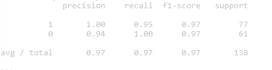

[**car**](https://archive.ics.uci.edu/ml/datasets/Car+Evaluation)

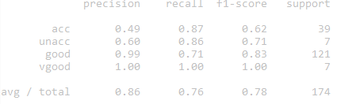

[**haberman**](https://archive.ics.uci.edu/ml/datasets/Haberman's+Survival)

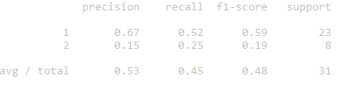

[**blood**](https://archive.ics.uci.edu/ml/datasets/Blood+Transfusion+Service+Center)

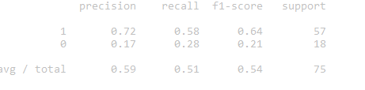

[**yeast**](https://archive.ics.uci.edu/ml/datasets/Yeast)

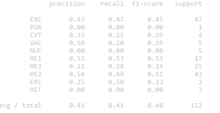

**Breastcancer**

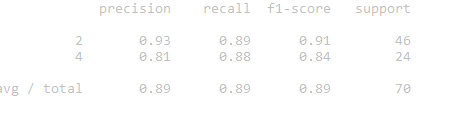

[**customer**](https://archive.ics.uci.edu/ml/datasets/Wholesale+customers)

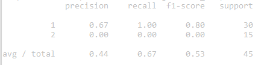